# MA models

## Definition Moving Average model order 1

An MA(1) is defined as:
$$y_t = \psi_0 +\psi_1 \ \epsilon_{t-1} +\epsilon_t$$
with the following assumptions $\forall t$:

- $\mathbb{E}[\epsilon_t]= 0$, $\mathbb{V}[\epsilon_t]= \sigma_{\epsilon}^2$ and the errors $\epsilon_{t_1}$ and $\epsilon_{t_2}$ are independent $\forall t_1\neq t_2$.
- $\mathbb{E}[y_t]= \mu_y=\psi_0$ (stationary in mean).
- $\mathbb{V}[y_t]= \sigma_y^2=\gamma_0=\mathbb{E}[ (\psi_1 \ \epsilon_{t-1} +\epsilon_t) (\psi_1 \ \epsilon_{t-1} +\epsilon_t) ]=(\psi_1^2+1)\ \sigma_{\epsilon}^2$ (stationary in variance).
- The covariance between $y_t$ and $y_{t-k}$ is:
  $$\mathbb{C}\text{ov}[y_t,y_{t-k}]=\gamma_k=\mathbb{E}[(y_t-\mu_y)(y_{t-k}-\mu_y)]=\mathbb{E}[(\psi_1 \ \epsilon_{t-1} +\epsilon_t) (\psi_1 \ \epsilon_{t-1-k} +\epsilon_{t-k})]$$
  hence $\gamma_k=0$ for $k>1$, and $\gamma_1=\psi_1 \ \sigma_{\epsilon}^2$.

consequently the autocorrelation between $y_t$ and $y_{t-k}$ is $ACF(0)=1$, $ACF(1)=\frac{\psi_1}{\psi_1^2+1}$ and $ACF(k)=0$ for $k>1$.

## ACF and PACF of MA(1)

In * arima.sim* the model simulated below corresponds to
$$y_{t}= \psi_1 \ \epsilon_{t-1} + \epsilon_{t}$$
with $\psi_1=0.8$.

```r
require(fma)
myts<-arima.sim(n=100000,list(order = c(0,0,1),ma = c(0.8)), sd = sqrt(0.1796))

# amplitude of ACF(1) usin
acf1=0.8/(1+0.8^2)
acf1
```

```
[1] 0.4878049
```

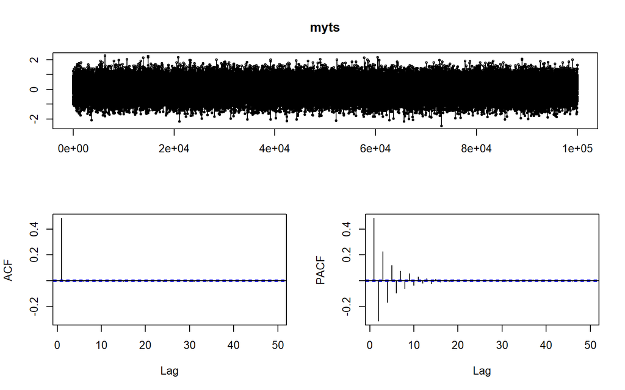

```r
tsdisplay(myts)
```

```r
# fitting the model MA(1) imposing $\mu_y=0$ since arima.sim uses  $\mu_y=0$
Arima(myts,order=c(0,0,1),include.mean = FALSE)
```

```
Series: myts
ARIMA(0,0,1) with zero mean

Coefficients:
         ma1
      0.7971
s.e.  0.0019

sigma^2 estimated as 0.179:  log likelihood=-55875.16
AIC=111754.3   AICc=111754.3   BIC=111773.4
```

- the ACF has one major peak at lag $k=1$ and then all ACF for $k>1$ are 0s.
- the PACF shows *damped sine wave* pattern which can be explained when rewritting the MA(1) as an AR($\infty$).

Read https://otexts.com/fpp2/MA.html about $AR(p)\equiv MA(\infty)$ and $MA(q)\equiv AR(\infty)$.